# Problem Set 5

Ji H. Kang

2020-11-13

```r
library(tidyverse)
library(ggplot2)
```

# Problem Set 5: Inference and Monte Carlo Simulations

For this problem set, we’ll be utilizing the “fathersons” data.

## 1. Are Sons Taller than Fathers?

### 1.1 Descriptive Analysis

```r
fathersons <- read.delim("../../Data/fatherson.csv.bz2")
cat("Number of missing observations for son's height:", sum(is.na(fathersons$sheight)), "\n")
```

```
## Number of missing observations for son's height: 0
```

```r
cat("Number of missing observations for father's height:", sum(is.na(fathersons$fheight)), "\n")
```

```
## Number of missing observations for father's height: 0
```

It’s shown that there are no missing observations from this dataset.

```r
# Stored values in-case I needed to do some testing on them specifically but it didn't seem like it.
# Kept them for debugging purposes. Variables are NOT needed.
f_mean <- mean(fathersons$fheight)
s_mean <- mean(fathersons$sheight)
f_median <- median(fathersons$fheight)
s_median <- median(fathersons$sheight)
f_sd <- sd(fathersons$fheight)
s_sd <- sd(fathersons$sheight)
cat("Mean of fathers' heights is:", f_mean, "cm.\n")
```

```
## Mean of fathers' heights is: 171.9252 cm.
```

```r
cat("Mean of sons' heights is:", s_mean, "cm.\n----------------------------------\n")
```

```
## Mean of sons' heights is: 174.4572 cm.
## ----------------------------------
```

```r
cat("Median of fathers' height is:", f_median, "cm.\n")
```

```
## Median of fathers' height is: 172.1 cm.
```

```r
cat("Median of sons' height is:", s_median, "cm.\n----------------------------------\n")
```

```
## Median of sons' height is: 174.3 cm.
## ----------------------------------
```

```r
cat("Standard deviation of fathers' height is:" , f_sd, "cm.\n")
```

```
## Standard deviation of fathers' height is: 6.972346 cm.
```

```r
cat("Standard deviation of sons' height is:", s_sd, "cm.\n")
```

```
## Standard deviation of sons' height is: 7.150713 cm.
```

```r
cat("The range of fathers' heights is:", max(fathersons$fheight) - min(fathersons$fheight), "cm.\n")
```

```
## The range of fathers' heights is: 41.7 cm.
```

```r
cat("The range of sons' heights is:", max(fathersons$sheight) - min(fathersons$sheight), "cm.\n")
```

```
## The range of sons' heights is: 50.4 cm.
```

It’s evident that sons, on average, have a higher height than fathers. This can be shown with sons having a mean height of 174.4572 cm with fathers having a mean of 171.9252 cm.  
One thing to note is that the sons height have a wider range (50.4 cm) versus that of fathers who have a range of (41.7cm). This, along with the standard deviation of sons being ~7.15 cm and fathers with 6.97 cm, shows that fathers tend to be more tightly clustered together in terms of their heights with sons having a slightly wider spread.

### Graphical Comparison

```r
# To make graphing easier, I manipulated the data to add a title value.
# I essentially made each column into their own respective rows and added a "title" column for father or son values.
sons <- data.frame(fathersons$sheight)
sons['title'] = "son"
names(sons)[1] <- "height"
fathers <- data.frame(fathersons$fheight)
fathers['title'] = "father"
names(fathers)[1] <- "height"
new_fathersons <- rbind(sons, fathers)
#Using this title value, I can graph both on the same figure.
```

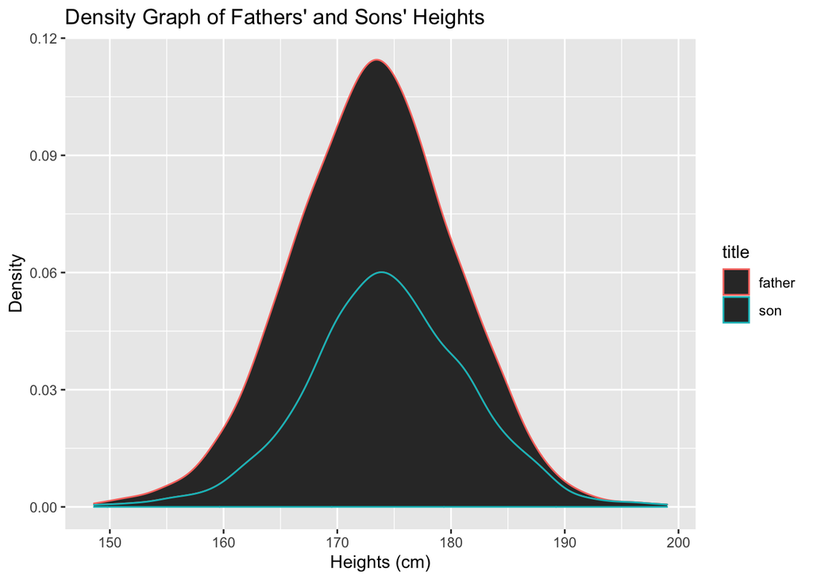

```r
ggplot(new_fathersons, aes(x=height, col=title)) +
  stat_density(aes(x=height)) +
  labs(title="Density Graph of Fathers' and Sons' Heights", x="Heights (cm)", y="Density")
```

```r
mean_diff <- mean(fathersons$sheight) - mean(fathersons$fheight)
cat("Sons are", round(mean_diff, 2), "cm taller than fathers on average.\n")
```

```
## Sons are 2.53 cm taller than fathers on average.
```

### 1.2 Monte Carlo Approach

To see if that there is statistical significance in sons being typically taller than their fathers, we’ll be conducting more experiments.

```r
#o_mean = overall mean, o_sd = overall standard deviation
o_mean <- mean(new_fathersons$height) # Values calculated prior
o_sd <- sd(new_fathersons$height)
cat("The overall mean of the data is:", o_mean, "cm.\n")
```

```
## The overall mean of the data is: 173.1912 cm.
```

```r
cat("The overall standard deviation of the data is:", o_sd, "cm.\n")
```

```
## The overall standard deviation of the data is: 7.173111 cm.
```

Now that we have the overall *mean* and overall *standard deviation*, we’ll be making two sets of random normal using the values we calculated just now.

```r
set.seed(1)
fakefathers <- rnorm(5, mean=o_mean, sd=o_sd)
fakesons <- rnorm(5, mean=o_mean, sd=o_sd)
real_mean_dif <- mean(sons$height) - mean(fathers$height)
cat("The difference in mean heights of these fake sets is:", mean(fakefathers) - mean(fakesons), "cm.\n")
```

```
## The difference in mean heights of these fake sets is: -0.04207584 cm.
```

In this specific instance, the difference is -0.042 cm. This is much lower than the one we’ve calculated for the actual data (Was ~2.5 cm). It could be explained by the fact that both sets (fakefathers and fakesons) are using the same mean and standard deviation.  
We’ll be repeating this experiment 10,000 times to be sure.

```r
sim <- function(x) {
  #Create random distributions of size nrow(fathersons) (approx 1078 observations)
  mean(rnorm(nrow(fathersons), mean=o_mean, sd=o_sd)) - mean(rnorm(nrow(fathersons), mean=o_mean, sd=o_sd))
}
diffs <- sapply(1:10000, sim)
```

```r
cat("The mean of differences is:", mean(diffs), "cm.\n")
```

```
## The mean of differences is: 0.002410113 cm.
```

The calculated mean of differences is 0.002 cm. Very close to 0. Since both distributions utilize the same mean and same standard deviation, they should have values that are very close to each other. Since we’re taking the difference of many values that are essentially the same, the overall difference is close to 0.

```r
cat("The standard deviation of the differences is:", sd(diffs), "cm.\n")
```

```
## The standard deviation of the differences is: 0.3111204 cm.
```

The standard deviation here is ~0.3 cm. This is very small compared to the previous values of ~6.9 cm and 7.1 cm of the fathers and sons respectively.

```r
max(diffs)
```

```
## [1] 1.309851
```

```r
min(diffs)
```

```
## [1] -1.298132
```

The biggest difference that occurred was 1.3098515 cm. While this is large compared to the average and standard deviation, it is much lower than the actual difference of 2.5 cm calculated beforehand.

```r
cat("The confidence interval is:\n")
```

```
## The confidence interval is:
```

```r
quantile(diffs, c(0.025, 0.975))
```

```
##       2.5%      97.5%
## -0.6035331  0.6060606
```

The actual difference is outside the interval range. It would suggest that 95% of the time, the height differences, **if** fathers and sons are the same height, falls within this confidence interval range. Based on this experiment, I can confidently say sons are taller than fathers. Given that the mean is close to 0 with the confidence interval being ~-0.6 to ~0.6 cm, the actual difference must fall within this range for fathers and sons to be considered the same height. Since it does not, it is statistically significant that sons are taller than their fathers on average.

# 1.3 t-test

```r
serror <- sd(diffs)/sqrt(length(diffs))
cat("The standard error computed is:", serror, "\n")
```

```
## The standard error computed is: 0.003111204
```

Next, we will calculate the t-value.

```r
fake_mean_dif <- mean(diffs)
real_diffs <- sons$height - fathers$height
t_value <- (mean(real_diffs) - mean(diffs)) / (sd(real_diffs) / sqrt(nrow(fathersons)))
cat("T value:", t_value, "\n")
```

```
## T value: 11.77153
```

With a t-value of 11, this is a very large value. Seeing the t-table distribution. Looking for values on the t-table, with a degree of freedom of 1077 (the size of fathersons minus 1), it’s becoming apparently that it’s increasingly confident. As the two tails values decrease, the confidence of the value increases but with our value (11) being so large, it goes off the table. It is in the realm of 99.9999…% chance of confidence. It seems highly unlikely that a t-value like this occurred by random chance.  
Based on the experiment so far, it seems that the actual difference we see is well outside the range of what’s if both father and sons are the same height. With a difference mean of ~2.5cm and with a experimental mean of ~0 cm, with a confidence interval of 95% ranging from roughly ~-0.6cm to ~0.6 cm, as well as a t-value of ~11.7, it’s clear that sons and fathers are not of similar height.